# A quick glance at reported robberies and thefts in Mexico City’s transportation system

Rebeca de Buen Kalman

5/8/2020

When the Mexico City Government published records of street level crime in 2019, I became curious about what these data might show about crime on different modes of transportation. Last week, I finally dived into this data set (because anything to get my mind off COVID-19 please) and here is what I learned when I analyzed four full years of crime reports, from 2016-2019.

#### The crime reports on modes of transportation are about violent robberies and non-violent thefts. Mass transit users report frequent thefts but most reports of crime on Metro and Metrobus are non-violent. Drivers report the most violent crime followed by peseros and Taxis.

The mode of transportation where people report the most violent crime is consistently the car. While mass transit users (Metro and Metrobus) also report large amounts of thefts, most of the reports from transit users are reported as non-violent. Pesero and Taxi users report less overall crimes but most of the reports of crime on these modes include violence.

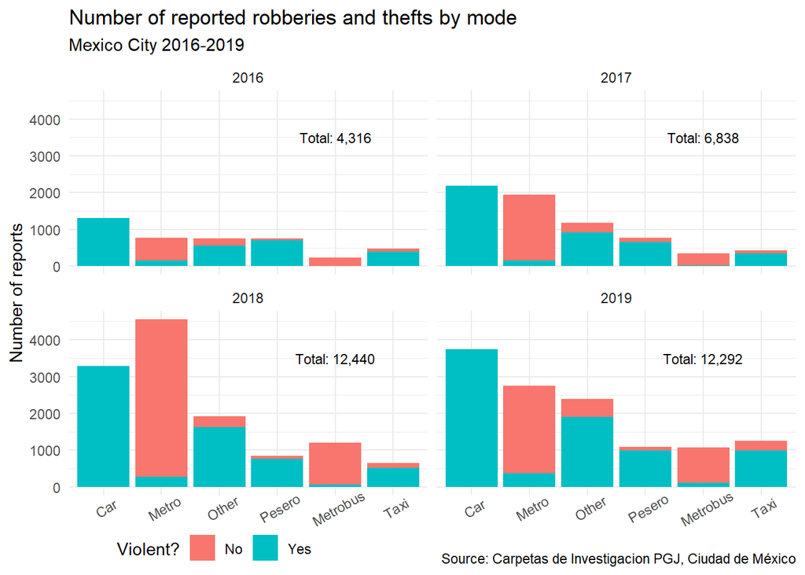

#### Reports of crime on transportation generally increased in 2018 but have mostly decreased since early 2019.

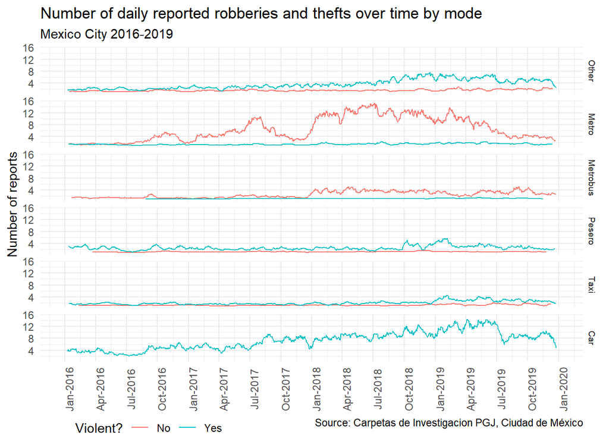

#### There is no clear pattern that indicates that any particular month of the year is more dangerous for any particular mode of transportation.

The reports of robberies on all modes of transportation vary randomly across months for all of the years analyzed. There does not appear to be any month of the year where robberies are consistently higher than other months.

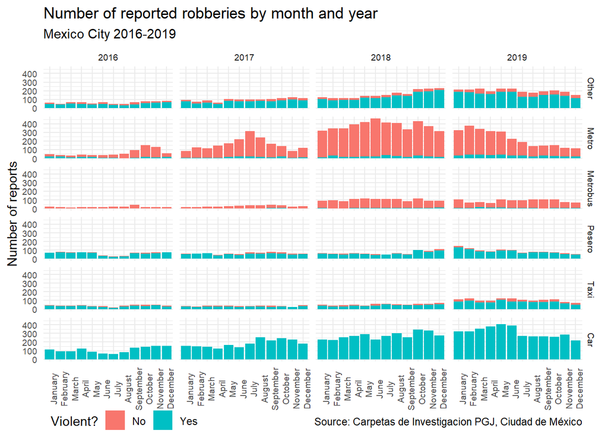

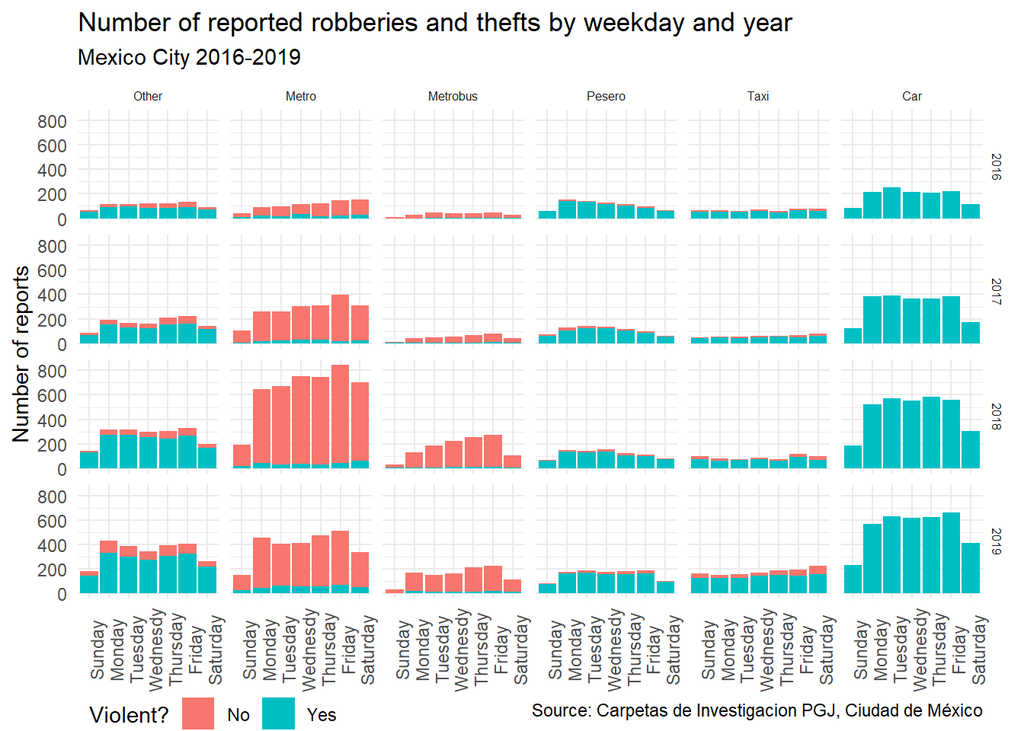

#### On public transportation, rhefts are most likely during peak commuting times. In cars, evenings are the most dangerous times for robberies.

On the Metro and Metrobus, times when thefts are most frequently reported match peak commuting times: Between 7-9am, 12-2pm and 6-8pm. Pesero crime reports have less data but seem to follow a similar pattern. For cars, on the other hand, reported robberies are consistently higher in the evenings, between 6-8pm.

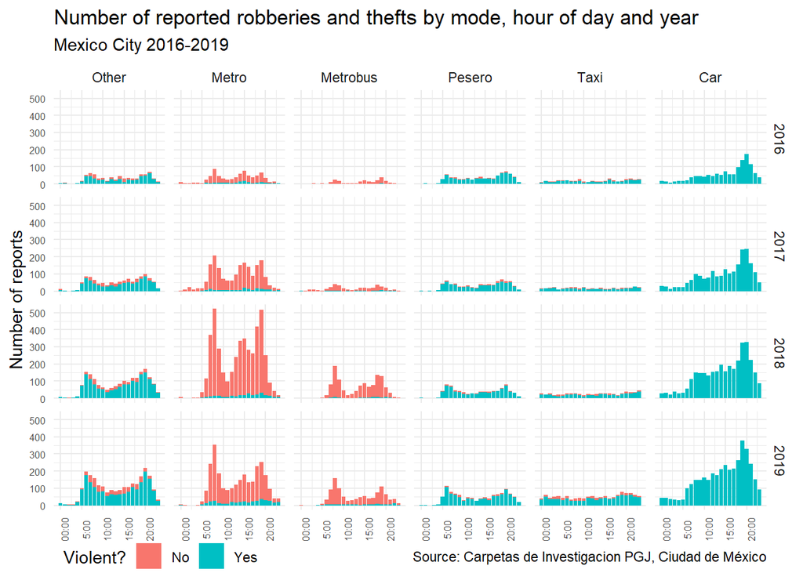

#### Taking a closer look at crimes reported on specific modes shows some geographical variations

**In the metro system, Hidalgo, Pantitlán, and Pino Suarez are the stations with the highest volume of reports of both robberies and thefts**

For thefts, Hidalgo, Pino Suárez, Pantitlán, Zócalo, and Chabacano. For robberies (that include violence) the top five stations where more crimes are reported are Hidalgo, Pantitlan, Pino Suárez, Tacuba and Zócalo. As a result, the neighborhoods where these stations are located (Centro, Guerrero, Pantiltlán) are the neighborhoods with the most reported crimes on metro stations.

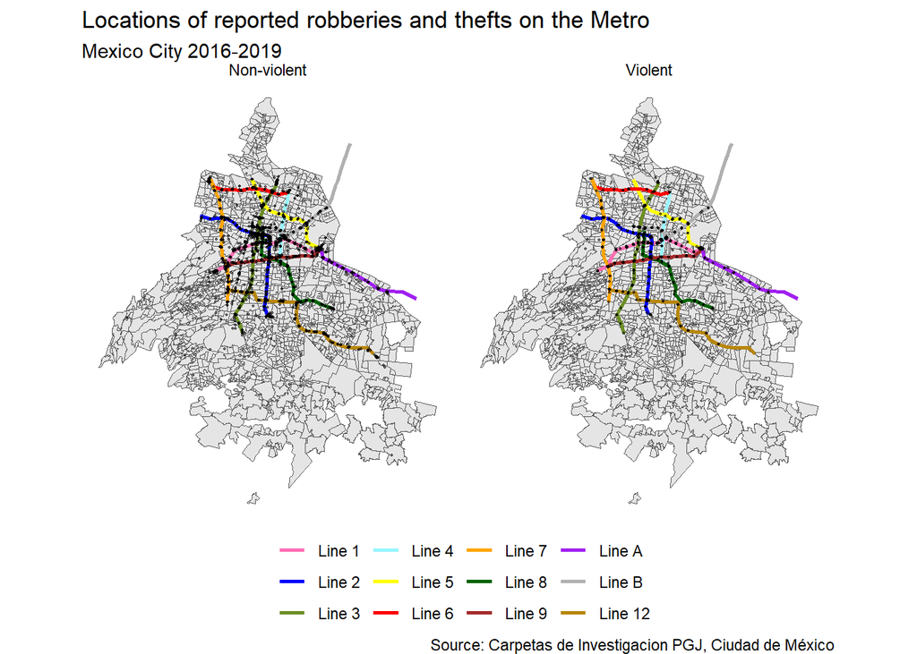

***Car Robberies are reported in many areas of the city**

The neighborhoods with the most reported car robberies are Tacubaya, Anahuac, Doctores, San Pedro de los Pinos, Daniel Garza and Morelos. Most of the reported robberies are reported in neighborhoods in the Álvaro Obregon, Miguel Hidalgo and Iztapalapa municipalities.

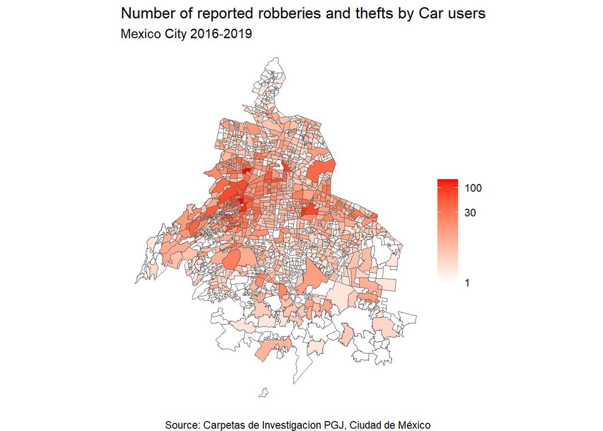

**Thefts and robberies reported on Peseros are laregly concentrated in neigborhoods en the east, with a large prportion in the Iztapalapa municipality**

The neighborhoods with the hightest number of reports include Ermita Zaragoza, Ejercito Constitucionalista, Santiago Atzacoalco, Martin Cabrera and Santa Marta Acatitla.

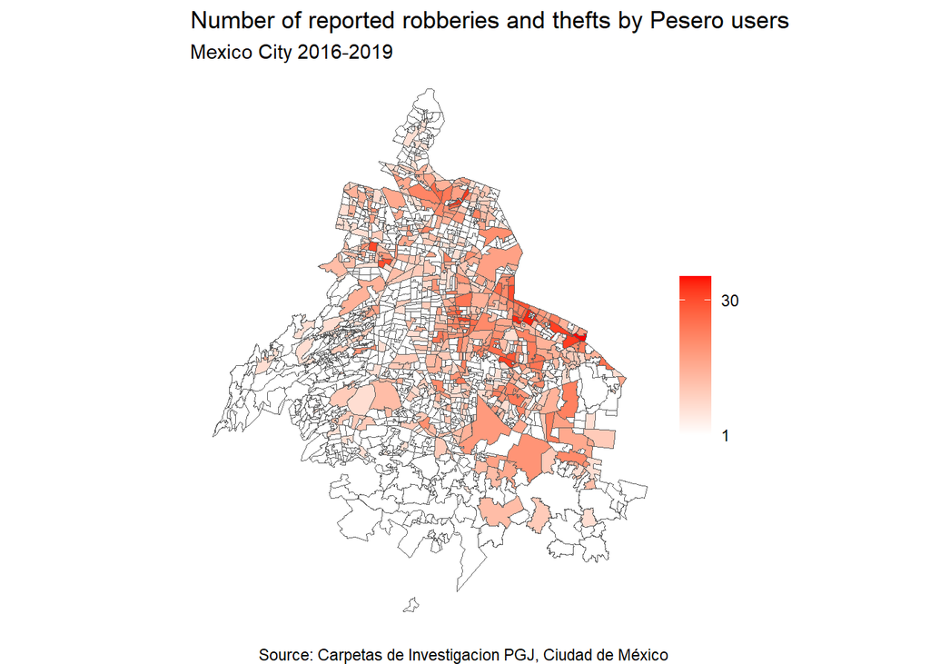

#### The details of this analysis can be found in this Appendix on the data and this Appendix on visualization

For a detailed description of how the data was processed, a more thurough discussion of the limitations of this post and full `R` code for cleaning and visualizing the data used in this analysis check these additional posts.